# Module 6 - Logistic Regression 1

2020-12-13

# Instructions

I am giving you both the raw data and the rendered Tables and Figures section. Your goal is to:

- Make a `rmd` file that knits to the `HTML` answer
- Answer the questions in the Analysis section by selecting the correct `[]` and filling out the `______`
- Hard coding the Analysis section is allowed
- Match the presented tables and/or figures in the Tables and Figures
- Do not hard code the Tables and Figures section

Please match the Analysis and Tables and Figures sections as close as you can.

Please submit both the `rmd` and your knitted `HTML` to the link on Canvas.

The data file is on Canvas as `data.csv`

**Remove the Instructions section from your final Knit.**

# Analysis

1. `Height` [is]/[is not] a significant predictor of `Improved` ($\beta$ = ______, $p$ = ______).
2. For each cm in `Height`, the Odds of the subject’s symptoms [improve]/[degrade] by ______ %.
3. `Weight` [is]/[is not] a significant predictor of `Improved` ($\beta$ = ______, $p$ = ______).
4. For each kg in `Weight`, the Odds of the subject’s symptoms [improve]/[degrade] by ______ %.

# Tables and Figures

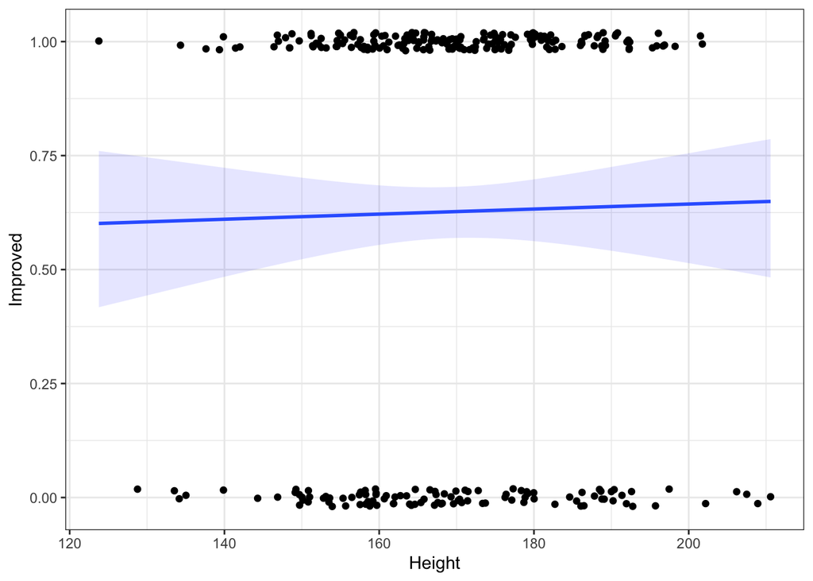

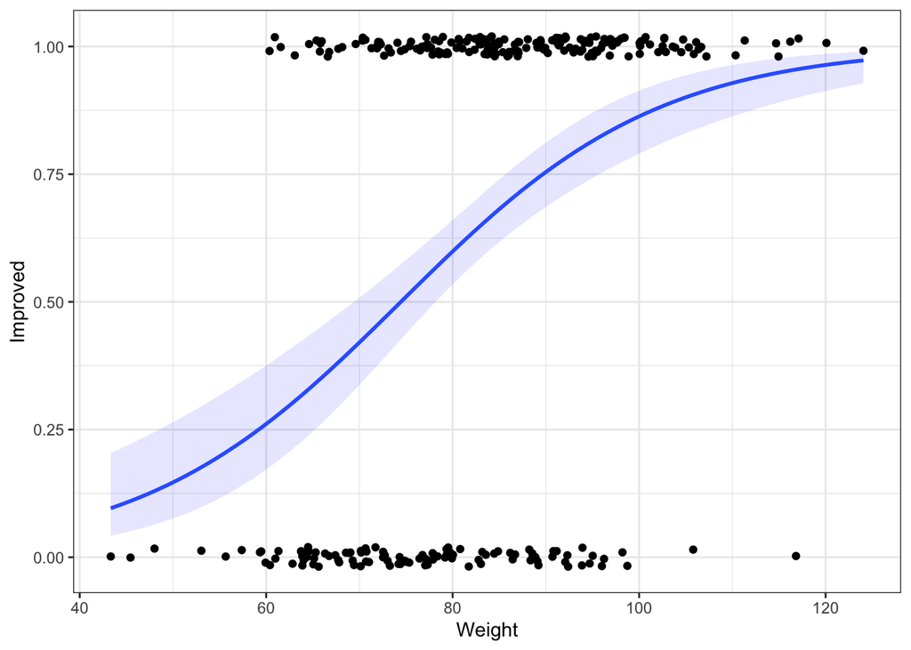